# STAT 516 Lec 04

Multiple linear regression (part 2/2)

Karl Gregory

2026-10-26

# SC apartments data

As in part 1/2, consider these data from “Apartment for Rent Classified” (2019)

```r
link <- url("https://gregorkb.github.io/data/scapts.csv")
scapts <- read.csv(link)
head(scapts)
```

```
  price nbath nbed sqft     city pets
1  1199     2    3 1200 Columbia  yes
2  1199     2    3 1450 Columbia  yes
3  1299     2    3 1950 Columbia  yes
4  1175     2    3 1312 Columbia  yes
5  1349     2    4 2015 Columbia  yes
6  1225     2    3 1336 Columbia  yes
```

```r
n <- nrow(scapts)
```

There are $n = 214$ observations.

# Setup

Consider data $(\mathbf{x}_1,Y_1),\dots,(\mathbf{x}_n,Y_n)$, with each $\mathbf{x}_i = (x_{i1},\dots,x_{ip})^T$.

The multiple linear regression model is

$$Y_i = \beta_0 + x_{i1}\beta_1 + \dots + x_{ip}\beta_p + \varepsilon_i, \quad i = 1,\dots,n,$$
where

- $\mathbf{x}_1,\dots,\mathbf{x}_n$ are vectors in $\mathbb{R}^p$ of covariate or predictor values.
- $Y_1,\dots,Y_n$ are the response values
- $\beta_0, \beta_1, \dots, \beta_p$ are the regression coefficients.
- $\varepsilon_1,\dots,\varepsilon_n$ are iid $\text{Normal}(0,\sigma^2)$ error terms.
- $\sigma^2$ is the error term variance.

# Goals in multiple linear regression

In part 1/2, we addressed these goals:

1. Estimate the regression coefficients $\beta_0$ and $\beta_1,\dots,\beta_p$.
2. Estimate the error term variance $\sigma^2$.
3. Perform inference on $\beta_1,\dots,\beta_p$.
4. Build a CI for $\beta_0 + \beta_1 x_{\operatorname{new},1} + \dots + \beta_p x_{\operatorname{new},p}$ at any $\mathbf{x}_{\operatorname{new}}$.
5. Build a prediction interval for $Y$ at any $\mathbf{x}_{\operatorname{new}}$.
6. Decompose the variation in $Y$ into (sums of) sums of squares.
7. Check whether the model assumptions are satisfied.
8. Identify outliers and understand their effects.
9. Include interaction effects.

# Goals in multiple linear regression (cont)

In part 2/2 we focus on these:

10. Test for significance of a subset of covariates.
11. Understand how correlations among the covariates affect inferences.
12. Do variable selection.

# Review of F distributions

For $W_1\sim \chi_{\nu_1}^2(\phi)$, $W_2 \sim \chi_{\nu_2}^2$ independent, $\displaystyle R = \frac{W_1 / \nu_1}{W_2 / \nu_2} \sim F_{\nu_1,\nu_2}(\phi)$.

$F_{\nu_1,\nu_2}(\phi)$ denotes the $F$ distribution with

- numerator degrees of freedom $\nu_1$
- denominator degrees of freedom $\nu_2$
- noncentrality parameter $\phi \geq 0$

If $\phi > 0$ the distribution is a non-central F distribution.

When $\phi = 0$ we just write $F_{\nu_1,\nu_2}$ to denote the “central” F distribution.

We will encounter ratios of sums of squares which have $F$ distributions.

# Plot of some F distribution pdfs

```r
nu1 <- c(1,2,3,5,5,5,50,50)
nu2 <- c(3,3,3,10,10,10,50,50)
phi <- c(0,0,0,0,4,8,0,4)
f <- seq(.01,4,length=200)
dfmat <- matrix(0,length(f),200)
for(j in 1:length(nu1)){

  dfmat[j,] <- df(f,df1 = nu1[j],df2=nu2[j],ncp=phi[j])

}
lab <- paste("(df1,df2,phi) = (",
      apply(cbind(nu1,nu2,phi),1,paste,collapse = ","),
      ")",sep="")
```

# Plot of some F distribution pdfs

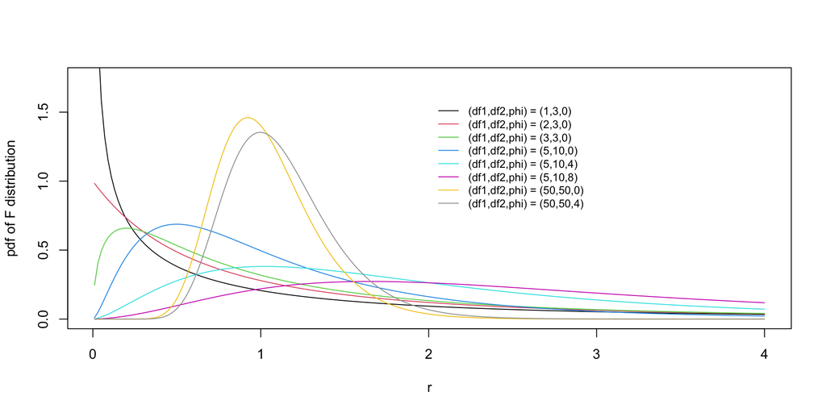

```r
plot(NA,xlim = range(f),ylim = c(0,1.2*max(dfmat[-1,])),
     xlab = "r",
     ylab = "pdf of F distribution")
for(j in 1:length(nu1)) lines(dfmat[j,]~f, col = j)
legend(x = .5*max(f),y = 1.1*max(dfmat[-1,]),legend = lab,
       col = 1:length(nu1), lty = 1,bty = "n", cex = .8)
```

# The overall F-test

We may wish to test whether *any* covariates are important, that is
$$\text{$H_0$: $\beta_j = 0$ for all $j = 1,\dots,p$}.$$

The overall F-test of significance is carried out as follows:

1. Fit the model with all the covariates and obtain the value
   $$F_{\operatorname{test}} = \frac{\operatorname{MS}_{\operatorname{Reg}}}{\operatorname{MS}_{\operatorname{Error}}} \left( = \frac{\operatorname{SS}_{\operatorname{Reg}}/ p}{\operatorname{SS}_{\operatorname{Error}}/ (n - (p+1))} \right)$$
2. Reject $H_0$ at $\alpha$ if $F_{\operatorname{test}} > F_{p,n - (p + 1),\alpha}$.
3. Obtain p-value is $P(F > F_{\operatorname{test}})$, where $F \sim F_{p,n-(p+1)}$.

This test statistic and p-value are reported by `summary()` on `lm()`.

# Exercise

Show that the test statistic of the overall F test can be written
$$F_{\operatorname{test}} = \frac{\operatorname{MS}_{\operatorname{Reg}}}{\operatorname{MS}_{\operatorname{Error}}} = \frac{(n - (p+1))}{p}\frac{R^2}{1 - R^2},$$
where $R^2$ is the coefficient of determination.

# SC apartments

```r
lm_out <- lm(log(price) ~ city + nbath + nbed + log(sqft) + pets +
               log(sqft):city, data = scapts)
summary(lm_out)
```

```
Call:
lm(formula = log(price) ~ city + nbath + nbed + log(sqft) + pets +
    log(sqft):city, data = scapts)

Residuals:
   Min     1Q Median     3Q    Max
-0.582 -0.133 -0.004  0.093  0.684

Coefficients:
                         Estimate Std. Error t value Pr(>|t|)
(Intercept)               2.88590    0.68527    4.21  3.8e-05 ***
cityColumbia              1.52500    0.75905    2.01   0.0459 *
cityGreenville            0.87340    0.88640    0.99   0.3256
cityRock Hill             0.33480    1.36863    0.24   0.8070
nbath                    -0.13511    0.04508   -3.00   0.0031 **
nbed                      0.07974    0.03470    2.30   0.0226 *
log(sqft)                 0.62871    0.10617    5.92  1.3e-08 ***
petsyes                  -0.00804    0.03089   -0.26   0.7949
cityColumbia:log(sqft)   -0.25861    0.11112   -2.33   0.0209 *
cityGreenville:log(sqft) -0.14616    0.13059   -1.12   0.2644
cityRock Hill:log(sqft)  -0.07234    0.19835   -0.36   0.7157
---
Signif. codes:  0 '***' 0.001 '**' 0.01 '*' 0.05 '.' 0.1 ' ' 1

Residual standard error: 0.207 on 203 degrees of freedom
Multiple R-squared:  0.43,  Adjusted R-squared:  0.402
F-statistic: 15.3 on 10 and 203 DF,  p-value: <2e-16
```

# Exercise

Suppose you fit a regression model with $p = 10$ predictors on a data set with $214$ observations, and you obtain $\hat \sigma = 0.207$ and $R^2 = 0.43$. It turns out that these pieces of information are sufficient to determine all the values in the ANOVA table. See if you can fill in all the values.

| Source | Df | SS | MS | F value | p-value |
| --- | --- | --- | --- | --- | --- |
| Reg | $p$ | $\operatorname{SS}_{\operatorname{Reg}}$ | $\operatorname{MS}_{\operatorname{Reg}}$ | $F_{\operatorname{test}}$ | $P(F > F_{\operatorname{test}})$ |
| Error | $n-(p+1)$ | $\operatorname{SS}_{\operatorname{Error}}$ | $\operatorname{MS}_{\operatorname{Error}}$ |  |  |
| Total | $n-1$ | $\operatorname{SS}_{\operatorname{Tot}}$ |  |  |  |

# Testing for significance of a subset of covariates

Consider testing the significance of a subset $D \subset \{1,\dots,p\}$ of covariates:
$$\text{$H_0$: $\beta_j = 0$ for all $j \in D$.}$$
Use the full-reduced model F-test:

1. Let $s$ be the number of covariates in $D$ and compute
   $$F_{\operatorname{test}} =\frac{(\operatorname{SS}_{\operatorname{Error}}(\text{Reduced}) - \operatorname{SS}_{\operatorname{Error}}(\text{Full}))/s}{\operatorname{SS}_{\operatorname{Error}}(\text{Full})/(n -(p+1))},$$
- “Full” is the model with all $p$ covariates.
- “Reduced” is the model after dropping the covariates in $D$.
2. Reject $H_0$ at $\alpha$ if $F_{\operatorname{test}} > F_{s,n-(p+1),\alpha}$.
3. Obtain p-value as $P(F > F_{\operatorname{test}})$, where $F \sim F_{s,n-(p+1)}$.

# SC apartments

Check whether the number of bedrooms or bathrooms contributes significantly to the rent.

That is, test $H_0$: $\beta_{\operatorname{nbath}} = \beta_{\operatorname{nbed}} = 0$.

Fit full and reduced model and obtain $\operatorname{SS}_{\operatorname{Error}}$:

```r
lm_red <- lm(log(price) ~ city + log(sqft) + pets + log(sqft):city, data = scapts)
lm_full <- lm(log(price) ~ city + nbath + nbed + log(sqft) + pets
              + log(sqft):city, data = scapts)
SSE_red <- sum(lm_red$residuals^2)
SSE_full <- sum(lm_full$residuals^2)
```

# SC apartments

- Full model:
  $$\begin{align*}
  \widehat{\log(\texttt{price})} = 2.886 &+ (1.525) \cdot \texttt{Columbia} + (0.873) \cdot \texttt{Greenville} \\
  &+ (0.335) \cdot \texttt{Rock Hill} + (-0.135) \cdot \texttt{nbath} \\
  &+ (0.08) \cdot \texttt{nbed} + (0.629) \log(\texttt{sqft}) \\
  &+ (-0.008) \cdot \texttt{pets} \\
  &+ (-0.259) \cdot \texttt{Columbia} \times \log(\texttt{sqft}) \\
  &+ (-0.146) \cdot \texttt{Greenville} \times \log(\texttt{sqft}) \\
  &+ (-0.072) \cdot \texttt{Rock Hill} \times \log(\texttt{sqft}).
  \end{align*}$$
- Reduced model (without $\texttt{nbath}$ and $\texttt{nbed}$):
  $$\begin{align*}
  \widehat{\log(\texttt{price})} = 3.15 &+ (0.892) \cdot \texttt{Columbia} + (0.872) \cdot \texttt{Greenville} \\
  &+ (0.117) \cdot \texttt{Rock Hill} + (0.581) \log(\texttt{sqft}) \\
  &+ (-0.007) \cdot \texttt{pets} \\
  &+ (-0.165) \cdot \texttt{Columbia} \times \log(\texttt{sqft}) \\
  &+ (-0.147) \cdot \texttt{Greenville} \times \log(\texttt{sqft}) \\
  &+ (-0.044) \cdot \texttt{Rock Hill} \times \log(\texttt{sqft}).
  \end{align*}$$

We obtain $\operatorname{SS}_{\operatorname{Error}}(\text{Full}) = 8.69$ and $\operatorname{SS}_{\operatorname{Error}}(\text{Reduced}) = 9.125$.

# SC apartments

Compute the test statistic for the full-reduced model F test.

```r
s <- 2 # significance of two covariates being tested
Ftest <- (SSE_red - SSE_full)/s / ( SSE_full / (n - (p + 1)))
alpha <- 0.05
F_crit <- qf(1 - alpha,s,n-(p+1))
pval <- 1 - pf(Ftest, s, n - (p+1))
```

We obtain $F_{\operatorname{test}} = 5.078$ and $F_{s,n-(p+1),0.05} = 3.04$, and the p-value is $0.007$.

# SC apartments

Check whether the city and its interactions are useful in the model.

```r
lm_red <- lm(log(price) ~ nbath + nbed + log(sqft) + pets, data = scapts)
lm_full <- lm(log(price) ~ city + nbath + nbed + log(sqft) + pets
              + log(sqft):city, data = scapts)
SSE_red <- sum(lm_red$residuals^2)
SSE_full <- sum(lm_full$residuals^2)
```

# SC apartments

- Full model:
  $$\begin{align*}
  \widehat{\log(\texttt{price})} = 2.886 &+ (1.525) \cdot \texttt{Columbia} + (0.873) \cdot \texttt{Greenville} \\
  &+ (0.335) \cdot \texttt{Rock Hill} + (-0.135) \cdot \texttt{nbath} \\
  &+ (0.08) \cdot \texttt{nbed} + (0.629) \log(\texttt{sqft}) + (-0.008) \cdot \texttt{pets} \\
  &+ (-0.259) \cdot \texttt{Columbia} \times \log(\texttt{sqft}) \\
  &+ (-0.146) \cdot \texttt{Greenville} \times \log(\texttt{sqft}) \\
  &+ (-0.072) \cdot \texttt{Rock Hill} \times \log(\texttt{sqft}).
  \end{align*}$$
- Reduced model (without the city variables and their interactions):
  $$\begin{align*}
  \widehat{\log(\texttt{price})} = 3.832 &+ (-0.112) \cdot \texttt{nbath} + (0.042) \cdot \texttt{nbed} \\
  &+ (0.483) \log(\texttt{sqft}) + (-0.06) \cdot \texttt{pets}
  \end{align*}$$

We obtain $\operatorname{SS}_{\operatorname{Error}}(\text{Full}) = 8.69$ and $\operatorname{SS}_{\operatorname{Error}}(\text{Reduced}) = 10.586$.

# SC apartments

Compute the test statistic for the full-reduced model F test.

```r
s <- 6 # significance of this many columns of X being tested
Ftest <- (SSE_red - SSE_full)/s / ( SSE_full / (n - (p + 1)))
alpha <- 0.05
F_crit <- qf(1 - alpha,s,n-(p+1))
pval <- 1 - pf(Ftest, s, n - (p+1))
```

We obtain $F_{\operatorname{test}} = 7.381$ and $F_{s,n-(p+1),0.05} = 2.143$, and the p-value is $3.723\times 10^{-7}$.

# Full-reduced model F test for a single covariate

If we test $H_0$: $\beta_j = 0$ for a single covariate using the full-reduced model F test, then:

1. The test statistic $F_{\operatorname{test}}$ will be equal to the square of the test statistic $T_{\operatorname{test}}$ for testing $H_0$: $\beta_j = 0$ in the full model.
2. The p-value will be the same as that of the test based on $T_{\operatorname{test}}$. This is due to the fact that $T \sim t_\nu$ implies $T^2 \sim F_{1,\nu}$.

# SC apartments

Use the full-reduced model F test to test whether the pets variable has an influence on the price.

```r
lm_red <- lm(log(price) ~ city + nbath + nbed + log(sqft) +
               log(sqft):city, data = scapts)
lm_full <- lm(log(price) ~ city + nbath + nbed + log(sqft) + pets
              + log(sqft):city, data = scapts)
SSE_red <- sum(lm_red$residuals^2)
SSE_full <- sum(lm_full$residuals^2)
s <- 1 # significance of a single covariate being tested
Ftest <- (SSE_red - SSE_full)/s / ( SSE_full / (n - (p + 1)))
pval <- 1-pf(Ftest,s,n-(p+1))
```

We obtain $\sqrt{F} = 0.26 = |T_{\operatorname{test}}|$. The p value is $0.795$. Compare this to that given in the `summary()` output.

# Effect of correlations among the covariates

From before $\operatorname{Var}\hat \beta_j = \sigma^2 \Omega_{jj}/n$. An alternate expression gives
$$\operatorname{Var}\hat \beta_j = \frac{1}{1 - R^2_j} \frac{\sigma^2}{\sum_{i=1}^n(x_{ji} - \bar x_j)^2},$$
where $R^2_j$ is the $R^2$ from regressing $x_j$ on the other covariates.

So multicollinearity of $x_j$ with the other covariates “inflates” $\operatorname{Var}\hat \beta_j$:

- Makes confidence intervals for $\beta_j$ wider.
- Makes tests of $H_0$: $\beta_j = 0$ vs $H_1$: $\beta_j \neq 0$ less powerful.

Call $\displaystyle \frac{1}{1- R^2_j}$ the variance inflation factor (VIF) for $x_j$, $j = 1,\dots,p$.

# SC apartments

Add to the data set a spurious predictor highly correlated with the square footage.

Check the effect of this on our inferences for $\beta_{\log(\operatorname{sqft})}$.

```r
# make new x correlated with square feet
x <- scapts$sqft + rnorm(n,0,50)
scaptsx <- cbind(scapts,x)
```

# SC apartments

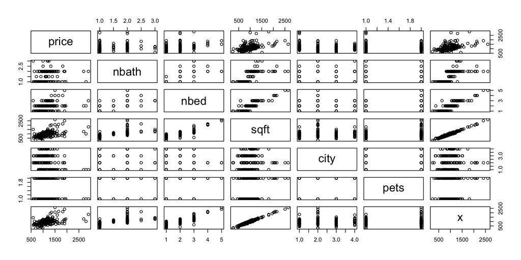

```r
plot(scaptsx)
```

# SC apartments

```r
lm_out <- lm(log(price) ~ city + nbath + nbed + log(sqft) + pets
             + log(sqft):city, data = scapts)
confint(lm_out)
```

```
                           2.5 %  97.5 %
(Intercept)               1.5347  4.2371
cityColumbia              0.0284  3.0216
cityGreenville           -0.8743  2.6211
cityRock Hill            -2.3638  3.0334
nbath                    -0.2240 -0.0462
nbed                      0.0113  0.1482
log(sqft)                 0.4194  0.8380
petsyes                  -0.0689  0.0529
cityColumbia:log(sqft)   -0.4777 -0.0395
cityGreenville:log(sqft) -0.4036  0.1113
cityRock Hill:log(sqft)  -0.4634  0.3187
```

# SC apartments

```r
lmx_out <- lm(log(price) ~ city + nbath + nbed + log(sqft) + pets
              + log(sqft):city + log(x), data = scapts)
confint(lmx_out)
```

```
                           2.5 %  97.5 %
(Intercept)               1.5277  4.2407
cityColumbia              0.0250  3.0271
cityGreenville           -0.8921  2.6512
cityRock Hill            -2.3715  3.0395
nbath                    -0.2242 -0.0457
nbed                      0.0111  0.1483
log(sqft)                 0.1214  1.1149
petsyes                  -0.0692  0.0535
log(x)                   -0.4489  0.4705
cityColumbia:log(sqft)   -0.4785 -0.0390
cityGreenville:log(sqft) -0.4081  0.1139
cityRock Hill:log(sqft)  -0.4643  0.3199
```

The width of the CI for $\beta_{\operatorname{log(sqft)}}$ *was* $0.419$.

With the new covariate the width of the CI for $\beta_{\operatorname{log(sqft)}}$ becomes $0.994$.

So including `log(x)` in the model makes our estimation of $\beta_{\operatorname{log(sqft)}}$ less accurate.

# SC apartments

```r
summary(lm_out)
```

```
Call:
lm(formula = log(price) ~ city + nbath + nbed + log(sqft) + pets +
    log(sqft):city, data = scapts)

Residuals:
   Min     1Q Median     3Q    Max
-0.582 -0.133 -0.004  0.093  0.684

Coefficients:
                         Estimate Std. Error t value Pr(>|t|)
(Intercept)               2.88590    0.68527    4.21  3.8e-05 ***
cityColumbia              1.52500    0.75905    2.01   0.0459 *
cityGreenville            0.87340    0.88640    0.99   0.3256
cityRock Hill             0.33480    1.36863    0.24   0.8070
nbath                    -0.13511    0.04508   -3.00   0.0031 **
nbed                      0.07974    0.03470    2.30   0.0226 *
log(sqft)                 0.62871    0.10617    5.92  1.3e-08 ***
petsyes                  -0.00804    0.03089   -0.26   0.7949
cityColumbia:log(sqft)   -0.25861    0.11112   -2.33   0.0209 *
cityGreenville:log(sqft) -0.14616    0.13059   -1.12   0.2644
cityRock Hill:log(sqft)  -0.07234    0.19835   -0.36   0.7157
---
Signif. codes:  0 '***' 0.001 '**' 0.01 '*' 0.05 '.' 0.1 ' ' 1

Residual standard error: 0.207 on 203 degrees of freedom
Multiple R-squared:  0.43,  Adjusted R-squared:  0.402
F-statistic: 15.3 on 10 and 203 DF,  p-value: <2e-16
```

The p-value for `log(sqft)` is very small.

# SC apartments

```r
summary(lmx_out)
```

```
Call:
lm(formula = log(price) ~ city + nbath + nbed + log(sqft) + pets +
    log(sqft):city + log(x), data = scapts)

Residuals:
    Min      1Q  Median      3Q     Max
-0.5816 -0.1335 -0.0037  0.0931  0.6840

Coefficients:
                         Estimate Std. Error t value Pr(>|t|)
(Intercept)                2.8842     0.6879    4.19  4.1e-05 ***
cityColumbia               1.5261     0.7613    2.00   0.0463 *
cityGreenville             0.8796     0.8985    0.98   0.3288
cityRock Hill              0.3340     1.3721    0.24   0.8079
nbath                     -0.1350     0.0453   -2.98   0.0032 **
nbed                       0.0797     0.0348    2.29   0.0230 *
log(sqft)                  0.6181     0.2519    2.45   0.0150 *
petsyes                   -0.0079     0.0311   -0.25   0.7999
log(x)                     0.0108     0.2332    0.05   0.9631
cityColumbia:log(sqft)    -0.2588     0.1115   -2.32   0.0212 *
cityGreenville:log(sqft)  -0.1471     0.1324   -1.11   0.2679
cityRock Hill:log(sqft)   -0.0722     0.1988   -0.36   0.7168
---
Signif. codes:  0 '***' 0.001 '**' 0.01 '*' 0.05 '.' 0.1 ' ' 1

Residual standard error: 0.207 on 202 degrees of freedom
Multiple R-squared:  0.43,  Adjusted R-squared:  0.399
F-statistic: 13.9 on 11 and 202 DF,  p-value: <2e-16
```

The p-value for `log(sqft)` is not nearly as small when `log(x)` is included!

# Getting VIFs with `vif()` from the `car` package

We can use the R package `car` from Fox and Weisberg (2019).

First time must install the package with `install.package("car")`.

```r
library(car)
vif(lm_out)
```

```
                   GVIF Df GVIF^(1/(2*Df))
city           1.89e+08  3           23.97
nbath          2.97e+00  1            1.72
nbed           3.97e+00  1            1.99
log(sqft)      6.18e+00  1            2.49
pets           1.19e+00  1            1.09
city:log(sqft) 1.97e+08  3           24.12
```

```r
vif(lmx_out)
```

```
                   GVIF Df GVIF^(1/(2*Df))
city           1.95e+08  3           24.07
nbath          2.98e+00  1            1.73
nbed           3.97e+00  1            1.99
log(sqft)      3.46e+01  1            5.89
pets           1.20e+00  1            1.10
log(x)         3.01e+01  1            5.49
city:log(sqft) 2.02e+08  3           24.23
```

Note the change in VIF for `log(sqft)` due to including `x` in the model!

# Variable selection

Sometimes the number of potentially important predictors is quite large.

Large $p$ tends to increase the VIFs, leading to low power.

So we may wish to discard some predictors. We briefly discuss:

1. Best subset selection with Mallow’s $C(p)$
2. Forward and backward stepwise selection with AIC
3. LASSO selection

And most importantly:

- The dangers of naïve post-selection inference!!

# Best subset selection with Mallow’s $C_p$

Given $q$ available covariates, there are $2^q$ possible subset models (why?).

Mallow’s $C_p$ can be used to compare subset models: Let
$$C_p = (n - (p + 1))\left[\frac{\operatorname{MS}_{\operatorname{Error}}(\operatorname{subset})}{\operatorname{MS}_{\operatorname{Error}}(\operatorname{all})} - 1\right] + (p + 1),$$
where

- $p$ is the number of predictors *in the subset model*.
- $\operatorname{MS}_{\operatorname{Error}}(\operatorname{subset})$ is the $\operatorname{MS}_{\operatorname{Error}}$ of the subset model.
- $\operatorname{MS}_{\operatorname{Error}}(\operatorname{all})$ is the $\operatorname{MS}_{\operatorname{Error}}$ of the model with all the covariates.

If the subset model is adequate, $\operatorname{MS}_{\operatorname{Error}}(\operatorname{subset})$ estimates the same target as $\operatorname{MS}_{\operatorname{Error}}(\operatorname{all})$, so the first term should be small and $C_p \approx p+1$.

Can look at $C_p$ values for all subset models of each size $p=0,1,2,\dots,q$

Want smallest model such that $C_p \approx p+1$.

# SC apartments

Can run the following to identify best model of each size and obtain the Mallow’s $C_p$ statistic for each of these models.

```r
library(leaps) # first time run install.packages("leaps")
regsubsets_out <- regsubsets(log(price) ~ city + nbath + nbed + log(sqft) + pets + log(sqft):city, data = scapts)
summary(regsubsets_out) # see best model of each size
summary(regsubsets_out)$cp # get corresponding Cp values
```

# 赤池 弘次 (あかいけひろつぐ)

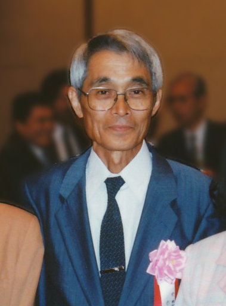

Introduced Akaike’s Information Criterion (AIC).

# Akaike’s Information Criterion (AIC) for comparing models

For a given model, i.e. set of covariates, AIC is defined as

$$\operatorname{AIC}= 2(p+1) - 2~\underbrace{\ell(\hat \sigma^2, \hat \beta_0,\hat \beta_1,\dots,\hat \beta_p)}_{\text{log-likelihood}}.$$
The log-likelihood is the log of the joint pdf of the data (STAT 512).

AIC can be used to compare several models for the same data.

The “best” model is the one which minimizes AIC.

# Stepwise selection based on AIC

Stepwise selection:

- Backward: Begin with all the predictors and remove one at a time.
- Forward: Begin with no predictors and add one at a time.

In each step remove/add predictor to get largest decrease in AIC.

If a decrease in AIC is not possible, stop.

# SC apartments

Below we run backward selection with the `step()` function:

```r
lm_intercept <- lm(log(price) ~ 1, data = scapts)
lm_all <- lm(log(price) ~ city + nbath + nbed + log(sqft) + pets + log(sqft):city, data = scapts)

# backward selection
step_back <- step(lm_all,
                  direction = "backward",
                  scope = formula(lm_all))
```

```
Start:  AIC=-664
log(price) ~ city + nbath + nbed + log(sqft) + pets + log(sqft):city

                 Df Sum of Sq  RSS  AIC
- pets            1     0.003 8.69 -666
- city:log(sqft)  3     0.244 8.93 -664
<none>                        8.69 -664
- nbed            1     0.226 8.92 -660
- nbath           1     0.385 9.07 -656

Step:  AIC=-666
log(price) ~ city + nbath + nbed + log(sqft) + city:log(sqft)

                 Df Sum of Sq  RSS  AIC
<none>                        8.69 -666
- city:log(sqft)  3     0.257 8.95 -665
- nbed            1     0.224 8.92 -662
- nbath           1     0.386 9.08 -658
```

# SC apartments

The chosen model has all the covariates except $\texttt{pets}$.

# SC apartments

Here we run forward selection with the `step()` function:

```r
# forward selection
step_forw <- step(lm_intercept,
                  direction = "forward",
                  scope = formula(lm_all))
```

```
Start:  AIC=-563
log(price) ~ 1

            Df Sum of Sq  RSS  AIC
+ log(sqft)  1      4.16 11.1 -630
+ nbed       1      2.73 12.5 -604
+ nbath      1      1.31 13.9 -581
+ city       3      1.03 14.2 -572
<none>                   15.2 -563
+ pets       1      0.02 15.2 -562

Step:  AIC=-630
log(price) ~ log(sqft)

        Df Sum of Sq   RSS  AIC
+ city   3     1.834  9.25 -662
+ nbath  1     0.267 10.82 -633
+ pets   1     0.194 10.89 -631
<none>               11.08 -630
+ nbed   1     0.000 11.08 -628

Step:  AIC=-662
log(price) ~ log(sqft) + city

                 Df Sum of Sq  RSS  AIC
+ nbath           1    0.1529 9.10 -664
<none>                        9.25 -662
+ nbed            1    0.0358 9.21 -661
+ pets            1    0.0101 9.24 -660
+ city:log(sqft)  3    0.1228 9.13 -659

Step:  AIC=-664
log(price) ~ log(sqft) + city + nbath

                 Df Sum of Sq  RSS  AIC
+ nbed            1    0.1471 8.95 -665
<none>                        9.10 -664
+ city:log(sqft)  3    0.1804 8.92 -662
+ pets            1    0.0077 9.09 -662

Step:  AIC=-665
log(price) ~ log(sqft) + city + nbath + nbed

                 Df Sum of Sq  RSS  AIC
+ city:log(sqft)  3    0.2571 8.69 -666
<none>                        8.95 -665
+ pets            1    0.0163 8.93 -664

Step:  AIC=-666
log(price) ~ log(sqft) + city + nbath + nbed + log(sqft):city

       Df Sum of Sq  RSS  AIC
<none>              8.69 -666
+ pets  1    0.0029 8.69 -664
```

# SC apartments

For these data forward and backward stepwise selection resulted in the same model.

But this need not be the case!

# LASSO selection

The LASSO estimators $\hat \beta_0^L,\hat \beta_1^L,\dots,\hat \beta_p^L$ are obtained by minimizing
$$Q_\lambda(b_0,b_1,\dots,b_p) = \sum_{i=1}^n(Y_i - (b_0 + b_1 x_{i1} + \dots + b_p x_{ip}))^2 + \lambda \sum_{j=1}^p|b_j|,$$
where $\lambda > 0$ is a tuning parameter.

- The penalty term $\lambda \sum_{j=1}^p|b_j|$ can cause $\hat \beta^L_j = 0$ for some $j$.
- For $\lambda$ large enough, all the $\hat \beta^L_j$ will be equal to zero.
- So LASSO performs variable selection and estimation simultaneously.
- Drawback: Hard to build CIs based on $\hat \beta_0^L,\hat \beta_1^L,\dots,\hat \beta_p^L$.

# The dangers of post-selection inference

It is dangerous to:

1. Ask the data which variables to include in the model.
2. Use the same afterwards to perform inference on the coefficients.

**Illustration**:

Add 50 spurious predictors to the SC apartment prices data.

See how many we find to be significant.

```r
n <- nrow(scapts)
X <- matrix(rnorm(n*50),n,50)
colnames(X) <- paste("x",1:50,sep="")
scaptsX <- cbind(scapts,X)

lmX_out <- lm(log(price) ~ ., data = scaptsX)
```

# SC apartments with spurious covariates added

```r
summary(lmX_out)
```

```
Call:
lm(formula = log(price) ~ ., data = scaptsX)

Residuals:
    Min      1Q  Median      3Q     Max
-0.4069 -0.1059 -0.0098  0.0918  0.5983

Coefficients:
                Estimate Std. Error t value Pr(>|t|)
(Intercept)     6.72e+00   5.73e-02  117.41  < 2e-16 ***
nbath          -7.57e-02   4.37e-02   -1.73  0.08541 .
nbed            3.52e-02   4.37e-02    0.81  0.42173
sqft            4.61e-04   9.51e-05    4.85  2.9e-06 ***
cityColumbia   -2.70e-01   4.41e-02   -6.12  7.4e-09 ***
cityGreenville -1.45e-01   3.99e-02   -3.65  0.00036 ***
cityRock Hill  -1.16e-01   5.21e-02   -2.22  0.02801 *
petsyes        -1.27e-04   3.30e-02    0.00  0.99692
x1             -4.26e-02   1.63e-02   -2.61  0.00988 **
x2             -6.73e-03   1.74e-02   -0.39  0.69872
x3             -1.34e-02   1.67e-02   -0.80  0.42602
x4              1.80e-02   1.63e-02    1.10  0.27188
x5              3.44e-02   1.57e-02    2.19  0.02968 *
x6             -4.50e-02   1.55e-02   -2.91  0.00412 **
x7             -5.93e-03   1.66e-02   -0.36  0.72086
x8              2.53e-03   1.68e-02    0.15  0.88078
x9             -2.73e-02   1.56e-02   -1.75  0.08167 .
x10             8.99e-03   1.71e-02    0.53  0.59902
x11             2.28e-02   1.51e-02    1.51  0.13291
x12             1.50e-03   1.67e-02    0.09  0.92848
x13             2.63e-03   1.53e-02    0.17  0.86330
x14             1.52e-02   1.80e-02    0.84  0.40091
x15             2.07e-02   1.59e-02    1.30  0.19416
x16             1.62e-02   1.62e-02    1.00  0.32077
x17            -2.21e-02   1.66e-02   -1.34  0.18368
x18             7.99e-04   1.57e-02    0.05  0.95951
x19             2.09e-02   1.75e-02    1.20  0.23334
x20            -8.96e-03   1.56e-02   -0.57  0.56701
x21            -2.82e-02   1.60e-02   -1.76  0.07985 .
x22             6.12e-03   1.68e-02    0.36  0.71668
x23             9.89e-03   1.53e-02    0.65  0.51923
```

[output cut: 18 more lines]

```
x42             5.70e-03   1.54e-02    0.37  0.71096
x43             1.62e-03   1.61e-02    0.10  0.92012
x44             5.53e-03   1.64e-02    0.34  0.73577
x45             2.04e-02   1.60e-02    1.28  0.20373
x46            -1.29e-02   1.55e-02   -0.83  0.40503
x47             1.23e-02   1.58e-02    0.78  0.43867
x48            -4.58e-02   1.62e-02   -2.83  0.00526 **
x49             6.31e-05   1.39e-02    0.00  0.99638
x50            -7.86e-05   1.64e-02    0.00  0.99619
---
Signif. codes:  0 '***' 0.001 '**' 0.01 '*' 0.05 '.' 0.1 ' ' 1

Residual standard error: 0.201 on 156 degrees of freedom
Multiple R-squared:  0.589, Adjusted R-squared:  0.438
F-statistic: 3.92 on 57 and 156 DF,  p-value: 8.63e-12
```

# SC apartments with spurious covariates added

We reject $H_0$: $\beta_j = 0$ at $\alpha = 0.05$ for $4$ of the spurious predictors.

So the Type I error rate was $4/50 = 0.08$.

Now do backwards stepwise selection to throw some variables away.

Then see how many of the spurious predictors we find “significant”.

# SC apartments with spurious covariates added

```r
stepX_out <- step(lmX_out, data = scaptsX, trace = 0)
summary(stepX_out)
```

```
Call:
lm(formula = log(price) ~ nbath + sqft + city + x1 + x5 + x6 +
    x9 + x11 + x17 + x21 + x27 + x29 + x31 + x33 + x34 + x38 +
    x45 + x48, data = scaptsX)

Residuals:
    Min      1Q  Median      3Q     Max
-0.4359 -0.1020 -0.0111  0.0935  0.6932

Coefficients:
                Estimate Std. Error t value Pr(>|t|)
(Intercept)     6.68e+00   4.66e-02  143.47  < 2e-16 ***
nbath          -6.78e-02   3.49e-02   -1.95   0.0532 .
sqft            5.52e-04   5.57e-05    9.90  < 2e-16 ***
cityColumbia   -2.78e-01   3.88e-02   -7.16  1.6e-11 ***
cityGreenville -1.55e-01   3.43e-02   -4.53  1.0e-05 ***
cityRock Hill  -1.24e-01   4.44e-02   -2.78   0.0059 **
x1             -3.43e-02   1.41e-02   -2.44   0.0156 *
x5              3.75e-02   1.34e-02    2.79   0.0057 **
x6             -3.67e-02   1.35e-02   -2.71   0.0073 **
x9             -2.68e-02   1.32e-02   -2.02   0.0443 *
x11             2.91e-02   1.31e-02    2.23   0.0272 *
x17            -2.68e-02   1.41e-02   -1.90   0.0591 .
x21            -2.80e-02   1.38e-02   -2.02   0.0447 *
x27            -2.40e-02   1.39e-02   -1.73   0.0859 .
x29             2.66e-02   1.38e-02    1.93   0.0552 .
x31            -2.03e-02   1.36e-02   -1.49   0.1384
x33            -2.04e-02   1.31e-02   -1.55   0.1220
x34             2.32e-02   1.40e-02    1.66   0.0985 .
x38            -2.22e-02   1.38e-02   -1.60   0.1103
x45             2.03e-02   1.37e-02    1.49   0.1391
x48            -3.28e-02   1.42e-02   -2.31   0.0218 *
---
Signif. codes:  0 '***' 0.001 '**' 0.01 '*' 0.05 '.' 0.1 ' ' 1

Residual standard error: 0.19 on 193 degrees of freedom
Multiple R-squared:  0.543, Adjusted R-squared:  0.495
F-statistic: 11.5 on 20 and 193 DF,  p-value: <2e-16
```

# SC apartments with spurious covariates added

Backwards stepwise selection keeps $15$ of the $50$ spurios predictors.

Among these $15$, we reject $H_0$: $\beta_j = 0$ at $\alpha = 0.05$ for $7$ of them.

So the post-selection Type I error rate was $7 / 15= 0.467$ .

**WARNING**: Selecting variables and then getting p-values in the selected model often leads to *astonishingly* inflated Type I error rates.

# References

“Apartment for Rent Classified.” 2019. UCI Machine Learning Repository.

Fox, John, and Sanford Weisberg. 2019. *An R Companion to Applied Regression*. Third. Thousand Oaks CA: Sage. https://socialsciences.mcmaster.ca/jfox/Books/Companion/.